# Loaded Questions Scoring

April 12, 2020

[output not shown]

# Q1: What Hogwarts House would you place yourself in?

MC for this question: Amadeo

Actual answers:

| Hogwarts House | Wizards and witches |
| --- | --- |
| Gryffindor | Art, Avila, Evan |
| Hufflepuff | Dave, Dotty, Kathy |
| Ravenclaw | Amadeo, Heath, Laura, Lucia, Oliver |
| Slytherin | Carol, Eri, Fran, Jim, Michael |

Who had the most correct answers? (I ignored spelling mistakes when scoring.)

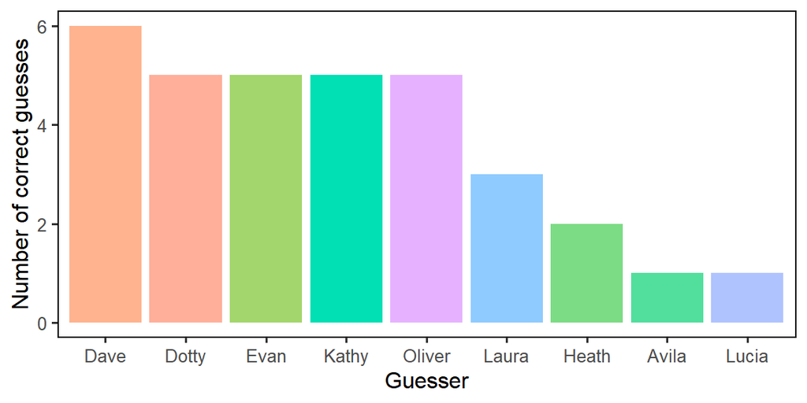

For each player, who guessed their answer correctly?

| Player | Who guessed correctly? |
| --- | --- |
| Amadeo | Dave, Laura, Dotty, Evan, Oliver, Kathy |
| Art | Oliver |
| Dotty | Heath, Kathy |
| Evan | Dave, Dotty, Kathy |
| Heath | Lucia, Dave, Laura, Dotty, Evan, Oliver, Kathy |
| Kathy | Avila, Dave, Dotty, Evan, Oliver |
| Laura | Dave, Dotty, Oliver |
| Lucia | Heath, Dave, Laura, Evan |
| Oliver | Evan, Kathy |

# Q2: Who is your favorite fictional antagonist?

MC for this question: Laura

| Player | Actual answer |
| --- | --- |
| Amadeo | Agent Smith |
| Art | Joker |
| Avila | Ego (Guardians of the Galaxy) |
| Dave | darth vader |
| Dotty | Shere Khan |
| Evan | Prof. Snape |
| Heath | The Joker |
| Kathy | The Earth (NK Jemisin Broken Earth trilogy) |
| Laura | Lady Catherine de Bourgh |
| Lucia | Hugh Tracy Clare Belmanoir, Duke of Andover |
| Oliver | Joker |

Who had the most correct answers? (“The Joker” and “Joker” were counted as being the same answer.)

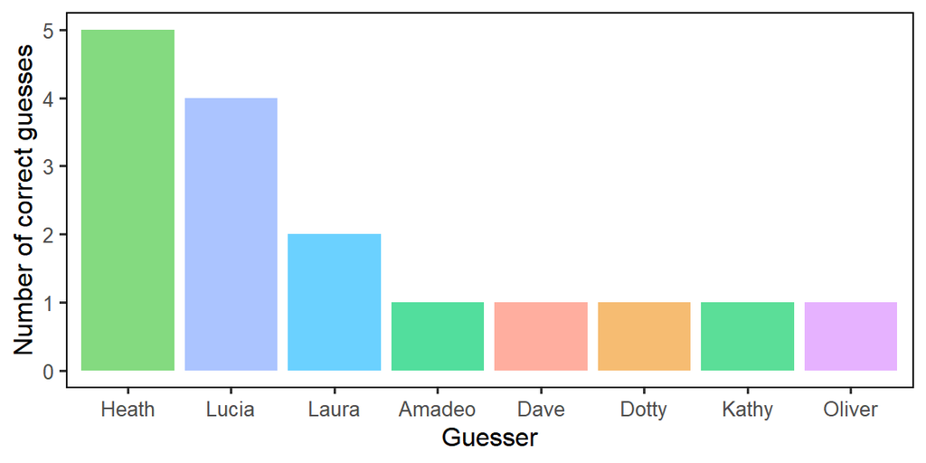

For each player, who guessed their answer correctly?

| Player | Who guessed correctly? |
| --- | --- |
| Amadeo | Heath, Lucia |
| Avila | Heath, Lucia |
| Dotty | Heath |
| Evan | Heath, Lucia, Kathy |
| Heath | Amadeo, Lucia, Dave, Laura |
| Laura | Dotty |
| Lucia | Heath, Laura, Oliver |

# Q3: What are you comically bad at?

MC for this question: Oliver

| Player | Actual answer |
| --- | --- |
| Amadeo | Resisting curiosity |
| Art | French language |
| Avila | acting casual when doing something naughty |
| Dave | shaking my booty |
| Dotty | Focusing |
| Evan | Chess |
| Heath | Not trying |
| Kathy | Cooking pancakes |
| Laura | basketball |
| Lucia | keeping my room clean |
| Oliver | Singing |

Who had the most correct answers?

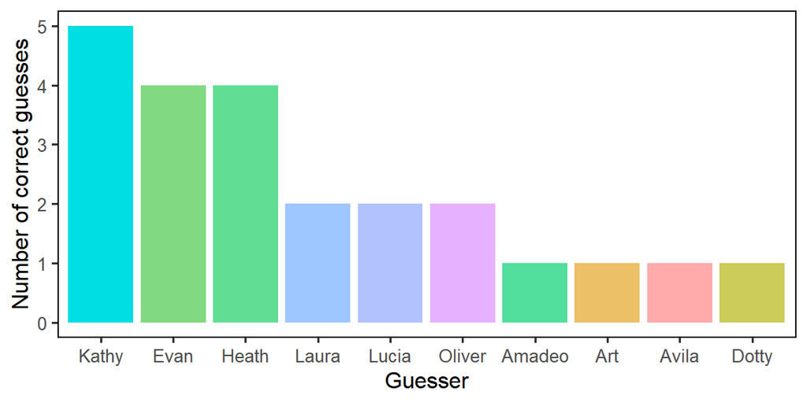

For each player, who guessed their answer correctly?

| Player | Who guessed correctly? |
| --- | --- |
| Amadeo | Heath, Lucia |
| Art | Evan, Kathy |
| Avila | Heath, Lucia |
| Dave | Heath, Laura, Dotty, Kathy |
| Dotty | Laura, Evan, Kathy |
| Evan | Kathy |
| Heath | Oliver |
| Kathy | Evan, Oliver, Art |
| Lucia | Heath, Amadeo, Avila, Evan |
| Oliver | Kathy |

# Q4: If you could witness a historical event, what would it be?

MC for this question: Heath

| Player | Actual answer |
| --- | --- |
| Amadeo | The KT event |
| Art | Battle of Gettysburg |
| Avila | the fall of the Berlin wall |
| Dave | 1968 Olympics |
| Dotty | The launch of the first American into space |
| Evan | 9/11 |
| Heath | When the first monolith taught the first protohuman to tie the first knot. |
| Kathy | Humanity getting out of quarentine |
| Laura | the Big Bang |
| Lucia | the reign of queen Victoria |
| Oliver | Lakers winning their 5th championship with Shaq and Kobe |

Who had the most correct answers?

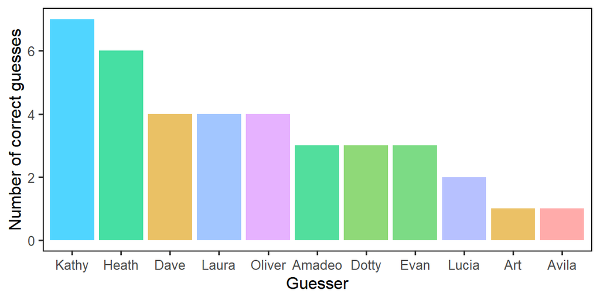

For each player, who guessed their answer correctly?

| Player | Who guessed correctly? |
| --- | --- |
| Amadeo | Heath, Dave, Laura, Dotty |
| Art | Amadeo, Dave |
| Avila | Heath, Laura, Kathy |
| Dave | Heath, Kathy |
| Evan | Heath, Dotty, Kathy |
| Heath | Amadeo, Lucia, Dave, Laura, Oliver, Kathy |
| Kathy | Evan, Oliver |
| Laura | Heath, Avila, Oliver, Kathy |
| Lucia | Heath, Amadeo, Laura, Dotty, Evan, Oliver, Kathy |
| Oliver | Lucia, Dave, Evan, Kathy, Art |

# Q5: What is the best present you ever received?

MC for this question: Kathy

| Player | Actual answer |
| --- | --- |
| Amadeo | Waking up every day so far. |
| Art | High quality kitchen knife |
| Avila | my life |
| Dave | Omega Speedmaster |
| Dotty | Birthday book with stories by friends & family |
| Evan | Hoverboard |
| Heath | A hat |
| Kathy | A coat 12 sizes too big |
| Laura | Aiden |
| Lucia | being born |
| Oliver | Disneyland |

Who had the most correct answers?

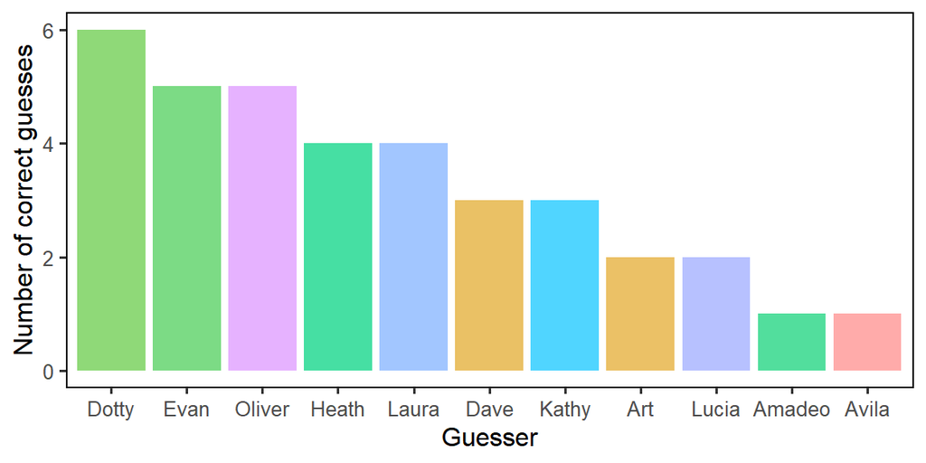

For each player, who guessed their answer correctly?

| Player | Who guessed correctly? |
| --- | --- |
| Amadeo | Dotty, Art |
| Art | Heath, Oliver |
| Dave | Heath, Oliver |
| Dotty | Laura, Evan, Oliver, Kathy, Art |
| Evan | Heath, Dave, Laura, Dotty, Oliver, Kathy |
| Heath | Lucia |
| Kathy | Dotty, Evan |
| Laura | Amadeo, Lucia, Avila, Dave, Dotty, Evan, Oliver |
| Lucia | Laura, Dotty, Evan |
| Oliver | Heath, Dave, Laura, Dotty, Evan, Kathy |

# Q6: What is your least favorite song?

MC for this question: Lucia

| Player | Actual answer |
| --- | --- |
| Amadeo | SeÃ±orita |
| Art | Chicken Dance |
| Avila | the “O’Reilly” song |
| Dave | Queensryche Silent Lucidity |
| Dotty | Who Let the Dogs Out? |
| Evan | Senorita |
| Heath | Anything sung by Bob Dylan |
| Kathy | Pumped Up Kicks |
| Laura | “Peaches” by the Presidents of the United States of America |
| Lucia | party in the USA |
| Oliver | Mine Diamonds |

Who had the most correct answers?

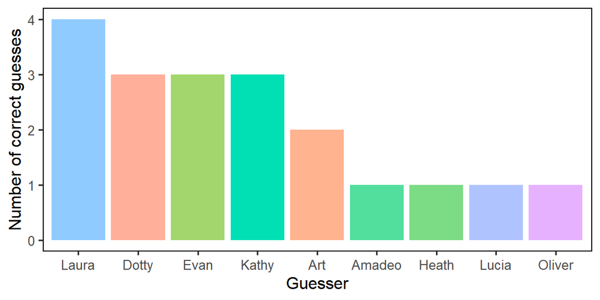

For each player, who guessed their answer correctly?

| Player | Who guessed correctly? |
| --- | --- |
| Amadeo | Art |
| Art | Laura, Dotty |
| Avila | Heath, Lucia |
| Dave | Laura, Evan, Kathy |
| Dotty | Laura |
| Evan | Oliver, Kathy |
| Kathy | Evan, Art |
| Laura | Dotty |
| Lucia | Dotty |
| Oliver | Amadeo, Laura, Evan, Kathy |

# Q7: What is your favorite ice cream topping?

MC for this question: Avila

| Player | Actual answer |
| --- | --- |
| Amadeo | Heath Bar |
| Art | Chocolate syrup |
| Avila | sour gummy worms/rings |
| Dave | butterfingercaramelchocolatesaucebutterscotchchips |
| Dotty | hot fudge |
| Evan | Cherries |
| Heath | Caramel |
| Kathy | Caramel |
| Laura | caramel and toasted pecans |
| Lucia | caramel |
| Oliver | Hot fudge |

Who had the most correct answers?

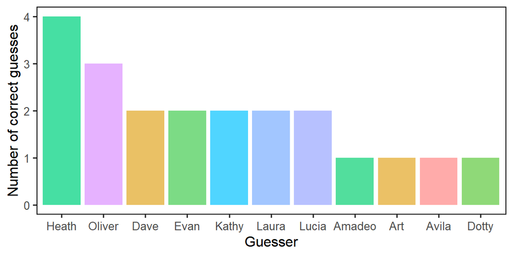

For each player, who guessed their answer correctly?

| Player | Who guessed correctly? |
| --- | --- |
| Amadeo | Heath, Avila |
| Avila | Heath, Lucia, Oliver |
| Dotty | Heath, Dave, Laura, Art |
| Evan | Oliver, Kathy |
| Heath | Amadeo |
| Kathy | Laura, Evan |
| Laura | Heath, Lucia |
| Lucia | Dave, Dotty, Oliver |
| Oliver | Evan, Kathy |

# Q8: Where is a great place to go camping?

MC for this question: Art

| Player | Actual answer |
| --- | --- |
| Amadeo | The back yard |
| Art | Moran State Park |
| Avila | a place in the woods were you can still see the stars |
| Dave | little wis wis |
| Dotty | Yellowstone |
| Evan | Orcas Island |
| Heath | The Brothers Wilderness |
| Kathy | Henry Coe State Park |
| Laura | the mountains |
| Lucia | in a tree |
| Oliver | La Wis Wis |

Who had the most correct answers?

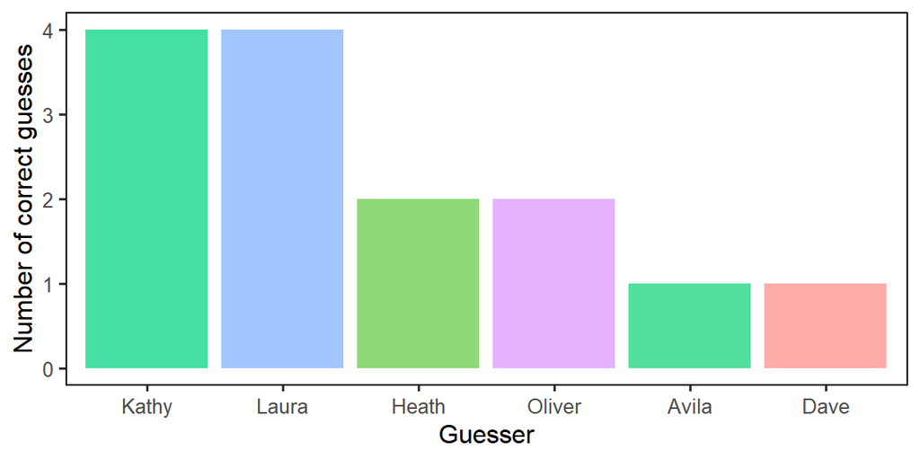

For each player, who guessed their answer correctly?

| Player | Who guessed correctly? |
| --- | --- |
| Art | Heath, Laura, Oliver, Kathy |
| Dave | Heath |
| Dotty | Laura, Oliver, Kathy |
| Evan | Dave, Kathy |
| Heath | Laura |
| Laura | Kathy |
| Lucia | Avila |
| Oliver | Laura |

# Overall scores

Overall MC: The Senator

Number of correct answers:

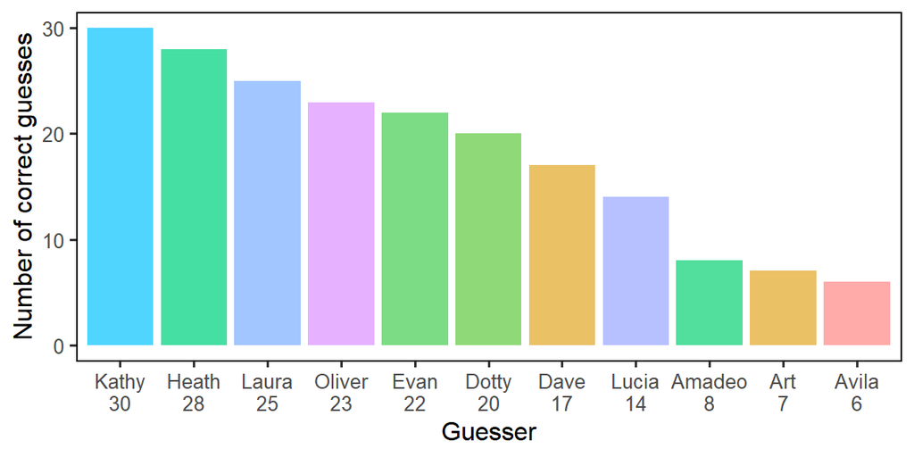

Who knows you best? Who guessed your answers correctly the most?

| Player | Known best by | Number of correct guesses |
| --- | --- | --- |
| Amadeo | Heath | 4 |
| Art | Oliver | 3 |
| Avila | Heath | 5 |
| Dave | Heath | 4 |
| Dotty | Laura | 5 |
| Evan | Kathy | 8 |
| Heath | Laura & Lucia | 4 |
| Kathy | Evan | 6 |
| Laura | Dotty | 4 |
| Lucia | Dotty & Evan & Heath & Laura | 4 |
| Oliver | Kathy | 6 |